# Исследование банкротства фирм.

**Состав команды:**

Ляпина Екатерина, Дмитрий Гайдаржи

Для анализа были взяты следующие данные: https://drive.google.com/file/d/0Bw_qUDxhcJMjdXNpTDhPb3R0alU/view?usp=sharing

**Объектом исследования** является финансовое состояние предприятия и индикаторы его способности расплатиться по долгам (банкротство) за итоговый период аудита.

**Предметом исследования** выступают причинно-следственные связи и зависимости экономических показателей, формирующиеся в результате деятельности фирмы.

**Цель работы:**

Установление структурных связей и закономерностей между элементами исследуемой системы в выбранной предметной области. Последующая интерпретация имеющихся данных, анализ применимости полученных результатов и создание наилучшей модели для дальнейшего прогнозирования подобных данных. В практическом смысле, аналитические модели могут успешно использоваться для решения задач выявления банкротства фирмы, и предупреждения подобных ситуаций.

**Задачи:**

Практическая задача сводится к необходимости выявления, в какой степени какие факторы определяют состоятельность компании и почему.

# Описание данных:

### Описание исходных переменных:

- **ID**: индекс записи, ее номер (в дальнейшем используется для выделения рандомных проверочных данных).
- **Ликвидность.активов** : экономический термин, обозначающий способность активов быть быстро проданными по цене, близкой к рыночной. Показатель изменяется от 0 до 1.
- **Рентабельность.активов** : показатель, который характеризует способность руководства компании эффективно использовать ее активы для получения прибыли. Этот коэффициент отражает среднюю доходность, полученную на все источники капитала (собственного и заемного), рассчитывается по формуле: рентабельность активов = чистая прибыль / активы
- **Доходность.активов** : чистая прибыль в процентном отношении к активам.
- **Автономность** : коэффициент финансовой независимости, характеризует отношение собственного капитала к общей сумме капитала организации. Коэффициент показывает, насколько организация независима от кредиторов. Чем меньше значение коэффициента, тем в большей степени организация зависима от заемных источников финансирование, тем менее устойчивое у нее финансовое положение.
- **Оборачиваемость.активов** : финансовый показатель интенсивности использования организацией всей совокупности имеющихся активов. Данный показатель используется наряду с другими показателями для анализа эффективности управления имуществом и обязательствами фирмы.
- **Банкрот** (зависимая переменная) : бинарная переменная (1 - да, 0 - нет), обозначает неспособность должника в полном объеме удовлетворить требования кредиторов по денежным обязательствам и (или) исполнить обязанность по уплате обязательных платежей.

Описательная статистика по нашей выбоке:

|  | ID | Ликвидность.активов | Рентабельность.активов | Доходность.активов | Автономность | Оборачиваемость.активов | Банкрот |
| --- | --- | --- | --- | --- | --- | --- | --- |
|  | Length:248 | Min. :0.0000000 | Min. :-8.994547754 | Min. :-8.114354465 | Min. :-0.95067398 | Min. : 0.0000000 | Min. :0.00 |
|  | Class :character | 1st Qu.:0.4548752 | 1st Qu.:-0.030530560 | 1st Qu.:-0.026613013 | 1st Qu.: 0.05171395 | 1st Qu.: 0.4609703 | 1st Qu.:0.00 |
|  | Mode :character | Median :0.6639313 | Median : 0.005235946 | Median : 0.008363906 | Median : 0.49220671 | Median : 1.1631490 | Median :0.00 |
|  | NA | Mean :0.6356584 | Mean :-0.083859172 | Mean :-0.069242899 | Mean : 2.11329067 | Mean : 1.4467805 | Mean :0.25 |
|  | NA | 3rd Qu.:0.8120194 | 3rd Qu.: 0.054041896 | 3rd Qu.: 0.072233372 | 3rd Qu.: 1.64777963 | 3rd Qu.: 2.0472354 | 3rd Qu.:0.25 |
|  | NA | Max. :1.0000000 | Max. : 1.500000000 | Max. : 1.798073030 | Max. :57.43253968 | Max. :17.8913391 | Max. :1.00 |

Диаграммы рассеивания для имеющихся переменных:

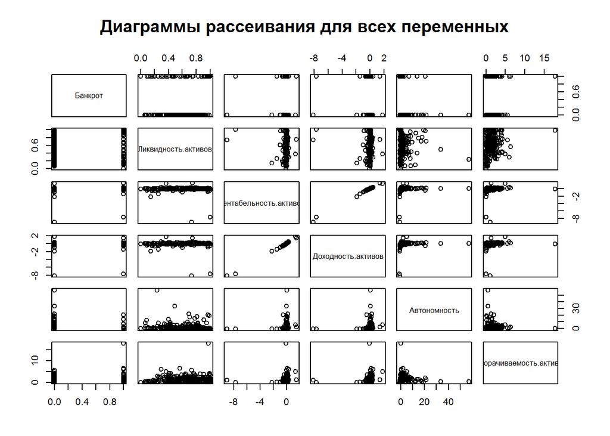

Мы решили исключить выбросы из наших данных. После преобразований диаграммы Бокса-Вискера для наших переменных стали такими:

Зависимости **Банкротства** от **Ликвидности активов**:

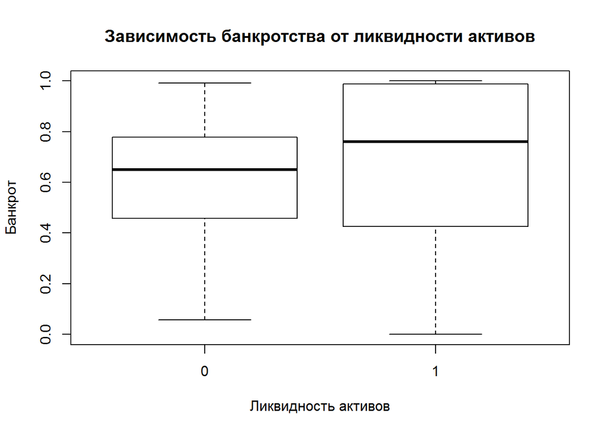

Построим диаграмму Бокса-Вискера для зависимости **Банкротства** от **Рентабельности активов**:

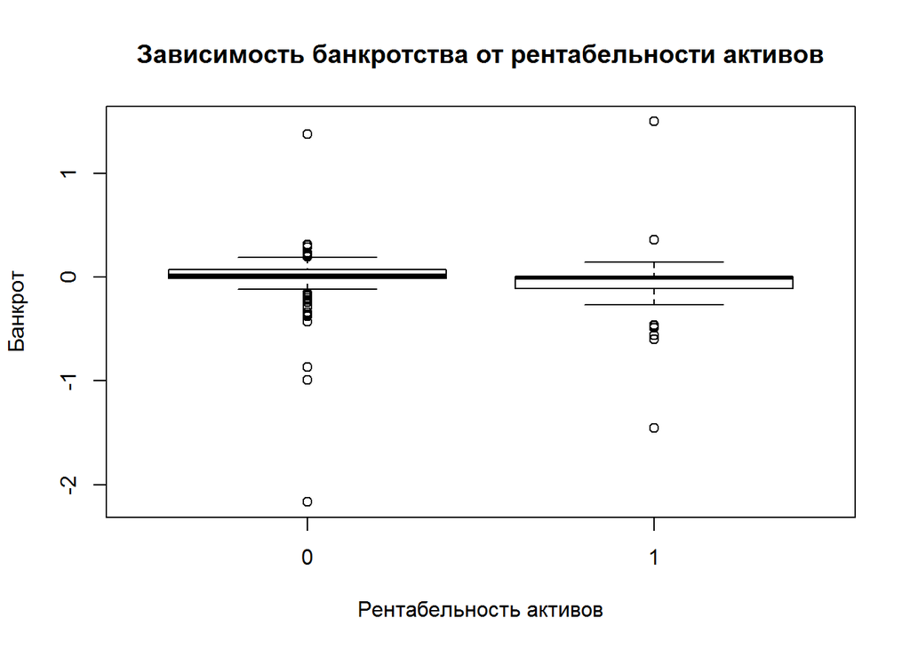

Построим диаграмму Бокса-Вискера для зависимость **Банкротства** от **Доходности активов**:

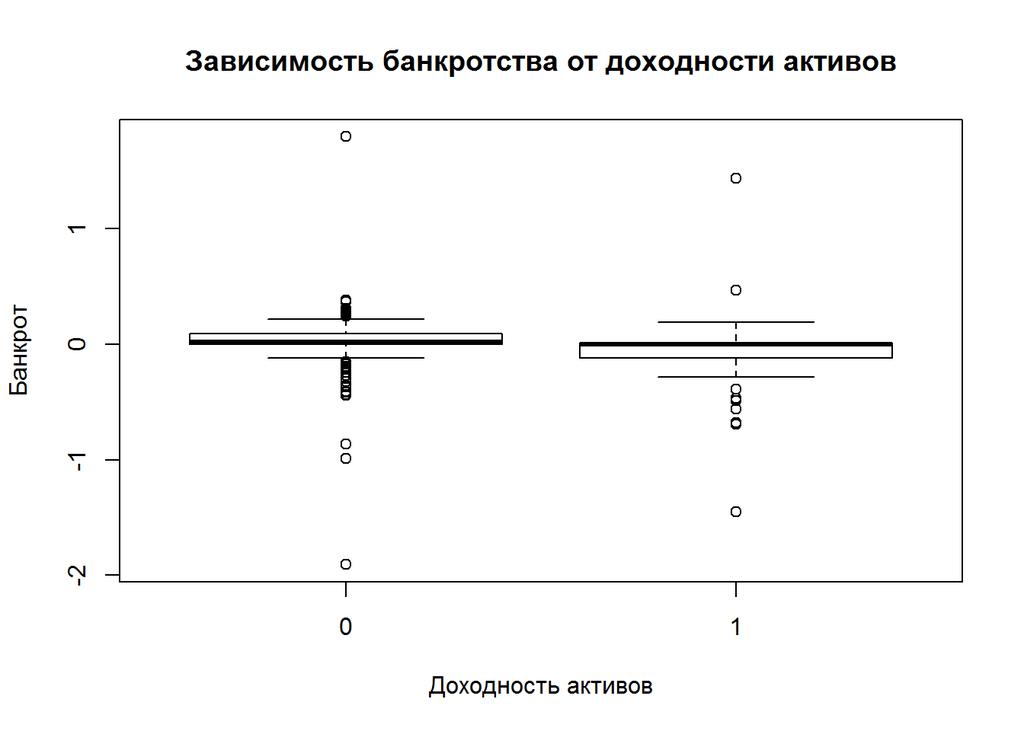

Построим диаграмму Бокса-Вискера для зависимости **Банкротства** от **Автономности активов**:

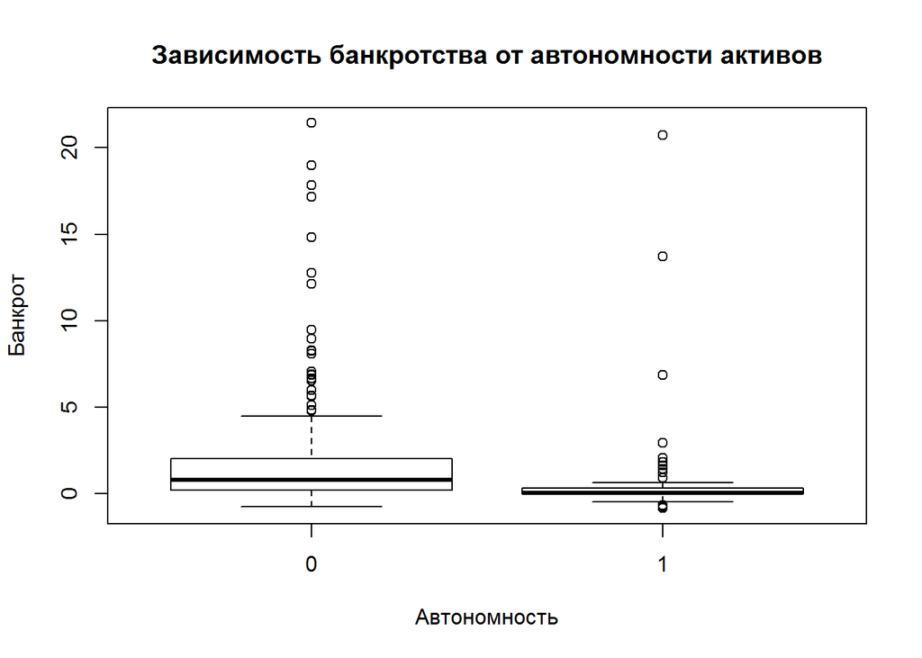

Построим диаграмму Бокса-Вискера для зависимости **Банкротства** от **Оборачиваемости активов**:

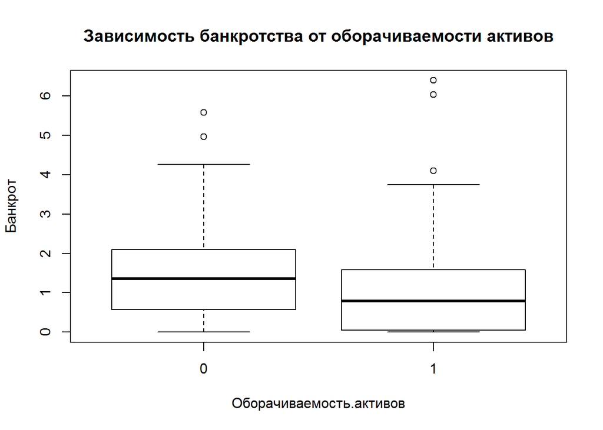

Для проверки полученной модели мы разделили все имеющиеся данные в соотношении 85:15. То есть тренировочными данными мы сделали 211 записей, мы выбрали их случайным образом из нашей выборки так, чтобы подвыборка была репрезентативная нашим данным.

Построим матрицу Пирсона для наших тренировочных данных:

|  | Ликвидность.активов | Рентабельность.активов | Доходность.активов | Автономность | Оборачиваемость.активов |
| --- | --- | --- | --- | --- | --- |
| Ликвидность.активов |  |  |  |  |  |
| Рентабельность.активов | 0.16* |  |  |  |  |
| Доходность.активов | 0.15* | 0.99*** |  |  |  |
| Автономность | 0.03 | 0.17* | 0.18** |  |  |
| Оборачиваемость.активов | 0.14* | 0.30*** | 0.34*** | 0.02 |  |
| Банкрот | 0.13 | -0.09 | -0.12 | -0.13 | -0.13 |

### Построение моделей и прогнозирование:

Построение моделей мы начали с бинарной логистической регрессии. Она наоболее всего подходит в случаях, когда зависимая переменная является дихотомической. Для нахождения коэффициентов логистической регрессии, использовался метод максимального правдоподобия, уже встроенный в пакет языка R.

В процессе исследования оказалось, что **Оборачиваемость активов** и **Автономность** мало влияют на **Банкротство**, эти переменные были исключены из итоговой модели. Полученная регрессия также применялась для прогнозирования.

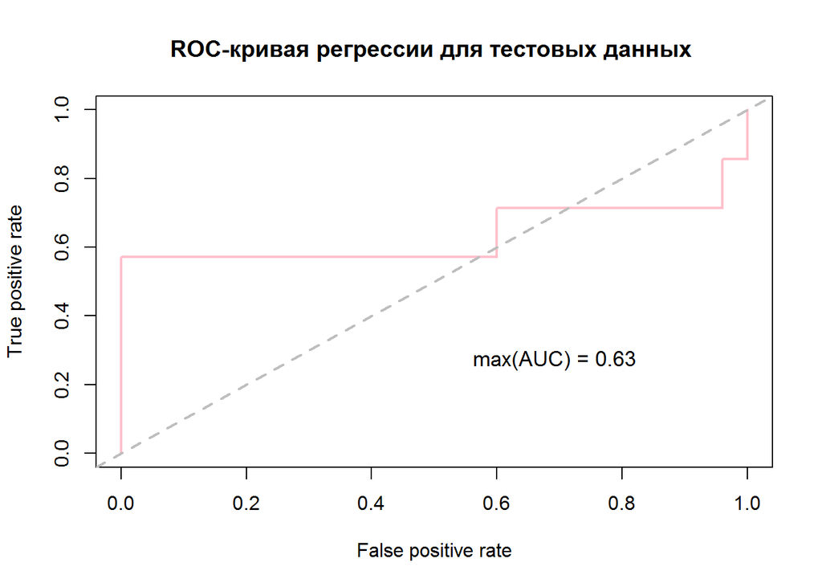

Мы используем ROC-кривую для представления результатов прогнозирования нашей модели. По сути мы построили функцию, которая считает долю истинно положительных примеров (True Positives Rate) и ложно положительных примеров (False Positives Rate). Мы взяли порог отсечения равным 0.4 для этих тестовых данных.

- TP (True Positives) – верно классифицированные положительные примеры (так называемые истинно положительные случаи);
- FP (False Positives) – отрицательные примеры, классифицированные как положительные (ошибка II рода); Это ложное обнаружение, т.к. при отсутствии события ошибочно выносится решение о его присутствии (ложно положительные случаи).

Мы также высчитываем показатель AUC(area under ROC curve) для выявления прогнозной силы нашей модели. Он также будет использоваться в последующем для сравнительного анализа нескольких моделей. В результате построения вышло, что наша модель имеет показатель AUC = 0.63. В литературе иногда приводится следующая экспертная шкала для значений AUC, по которой можно судить о качестве модели:

- AUC - Качество модели
- 0.9-1.0 - Отличное
- 0.8-0.9 - Очень хорошее
- 0.7-0.8 - Хорошее
- 0.6-0.7 - Среднее
- 0.5-0.6 - Неудовлетворительное

В последующем мы построили регрессионное дерево, воспользовавшись алгоритмом CART. Дерево было использовано для дальнейшего прогнозирования и сравнения моделей уже описанными способами.

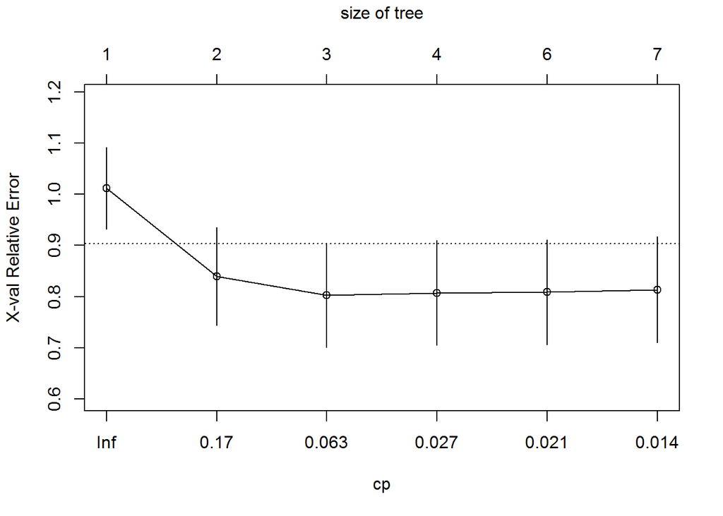

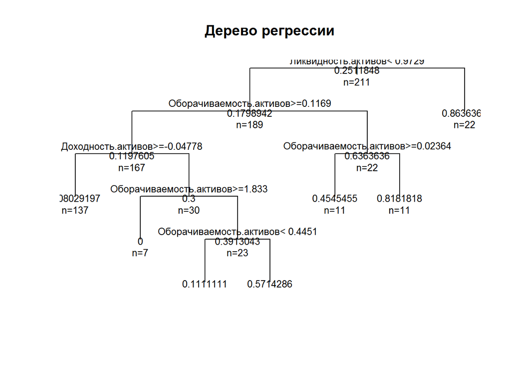

После выявления наилучшей модели мы также провели ROC-анализ:

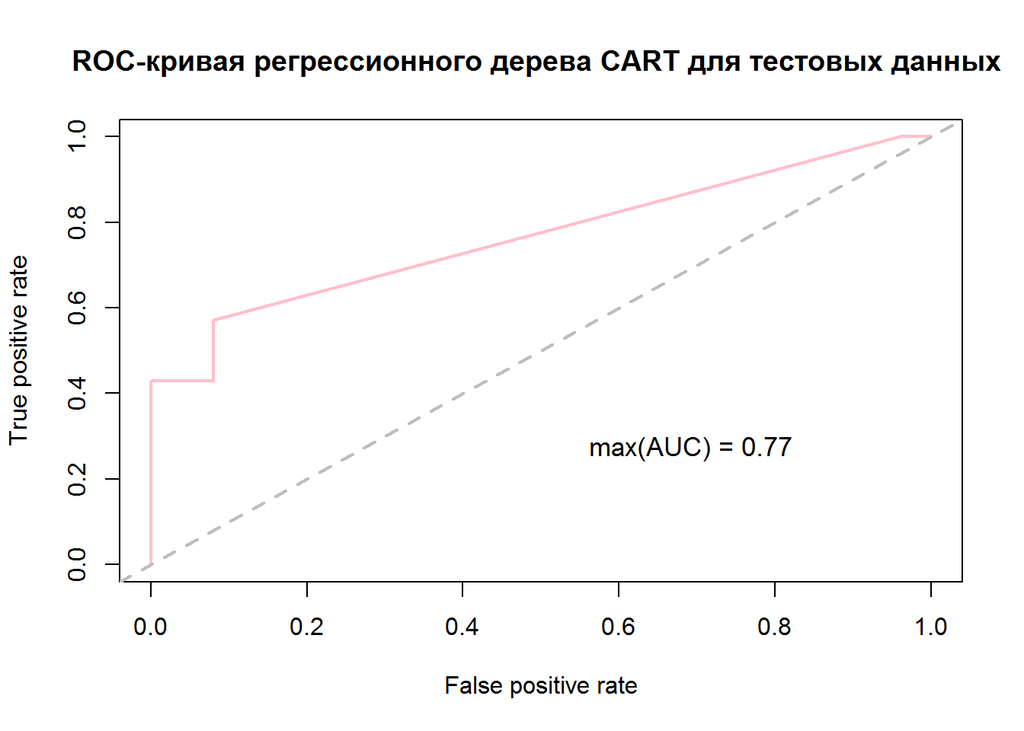

В результате построения вышло, что наша модель имеет показатель AUC равный 0.77. Мы также воспользовались методом random forests для дальнейшего прогнозирования и сравнения моделей. График количества ошибок от количества использованых в методе random forest деревьев выглядит следующим образом:

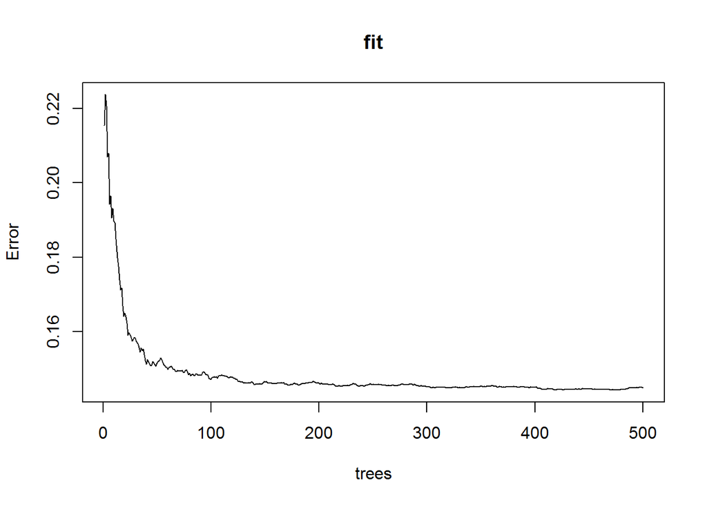

После построения мы также провели ROC-анализ:

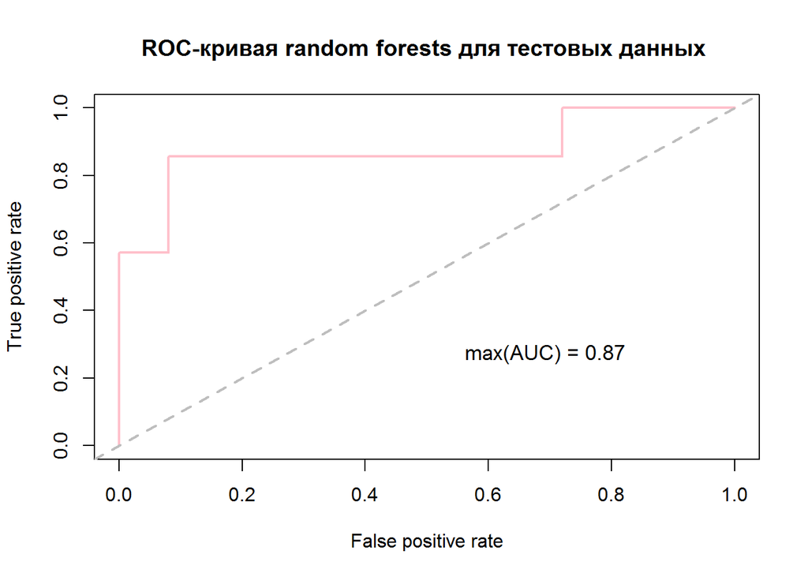

В результате построения вышло, что наша модель имеет AUC равный 0.87.

Последним регрессионным деревом стало дерево, построенное с использованием алгоритма C.5.0:

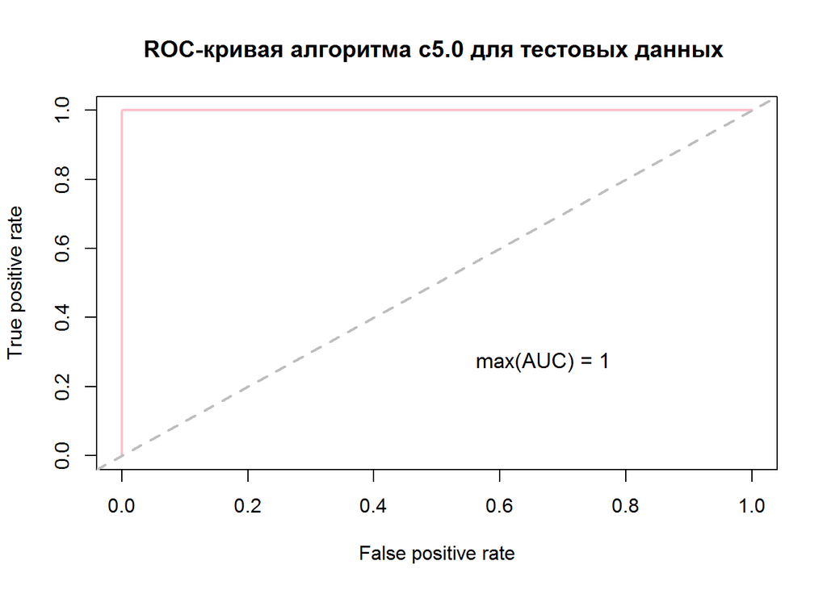

В результате построения вышло, что наша модель имеет AUC равный 1. Для полноты конкуренции мы отсроили также нейронную сеть (однослойный персептрон):

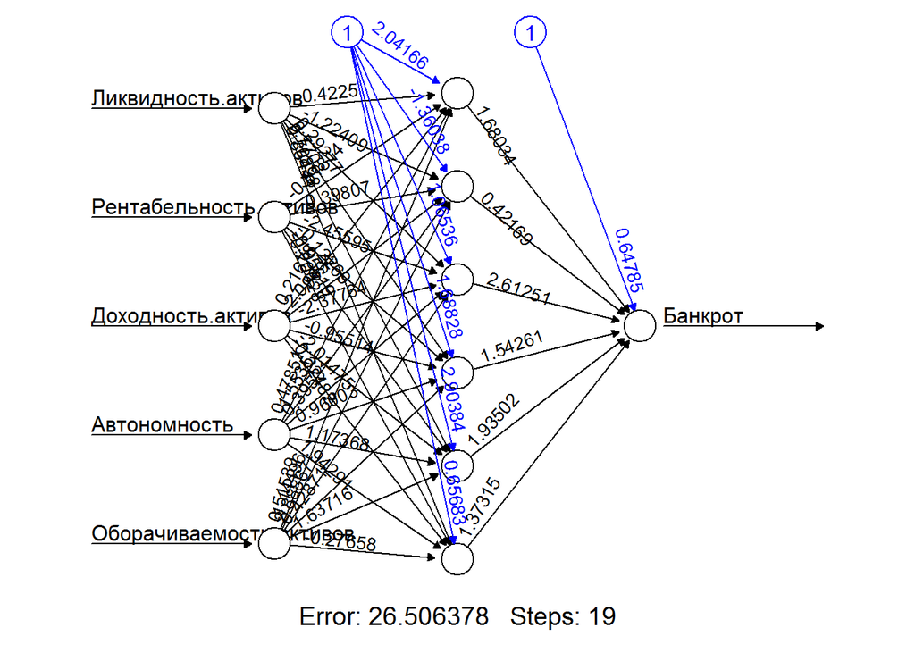

[figure not shown]

В результате построения вышло, что наша модель имеет AUC равный 0.5.